# A Brief Look into Gun Deaths

### Data Loading

The data is fairly clean, so not much processing is needed. A single record with an NA value for ‘intent’ was omitted, solely because it won’t help with the analysis.

```r
library(zoo)
library(lubridate)
library(tidyverse)
library(nnet)
library(pscl)

setwd('~/Programming/Projects/Guns')
guns <- read_csv('guns.csv')[, -1]

guns <- filter(guns, intent != 'NA')
guns$date <- as.yearmon(make_date(year = guns$year,  month = guns$month))
```

### Overall Yearly Trends by Intent

First, we’ll take a look at the overall yearly trends for deaths by intent, to see if anything looks peculiar. The trends look fairly consistent over the three years, with some apparent seasonality impacting the beginning of each year. Homicide deaths hover around 1,000 per month, while suicides remain around 1,750. Accidental and undetermined deaths are fairly low in comparison.

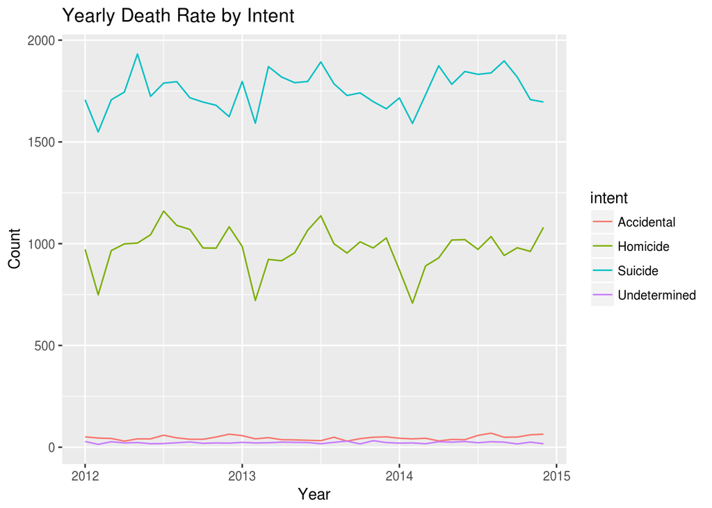

```r
guns %>%
  group_by(date, intent) %>%
  summarise(n = n()) %>%
  ggplot() +
    geom_line(mapping = aes(x = date, y = n, color = intent)) +
  labs(title = 'Yearly Death Rate by Intent', x = 'Year', y = 'Count')
```

It should be noted that the data is recorded by month. So the seasonality may just be due to the fact that different months contain a different number of days. For instance, February only has 28 days in a month (except for leap years), while December has 31 - which allows December three additional days for deaths to be recorded.

### Overall Monthly Trends by Intent

The plot below looks further into the possibility of seasonality. This plot depicts the average number of deaths by intent per day for any given month (leap years included). This means that the different number of days in February vs. December, for instance, will not have a factor into the supposed seasonality witnessed in the first plot.

As we can see, February is a month that has less homicides than other months; and suicides are less likely to happen during the month of December. On the other hand, the summer months contain a larger portion of homicides and suicides.

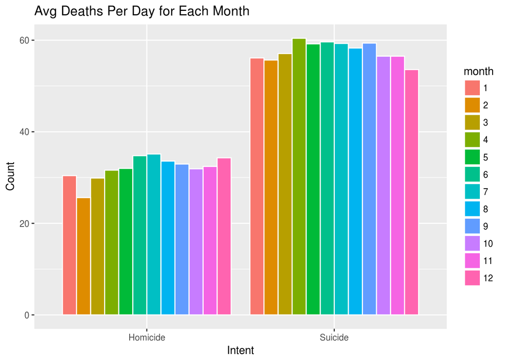

```r
guns %>%
  group_by(date, intent) %>%
  filter(intent == 'Homicide' | intent == 'Suicide') %>%
  summarise(n = n()) %>%
  mutate(month = factor(month(date)),
         days = days_in_month(date)) %>%
  group_by(month, intent) %>%
  summarise(total = sum(n), days = sum(days)) %>%
  mutate(days_avg = total/days) %>%
  ggplot() +
  geom_col(aes(x = intent, y = days_avg, fill = month), color = 'white',
           position = 'dodge') +
  labs(title = 'Avg Deaths Per Day for Each Month', x = 'Intent',
       y = 'Count')
```

### Intent Based on Demographics

Next, a multinomial model is applied to three different levels of intent: homicide, suicide and accidental (the latter is the reference category). The intent “undetermined” was omitted because it does not add to the analysis.

The analysis behind the multinomial model is to determine which demographic variables have a relationship with the different types of intent.

```r
guns_multi <- guns %>%
  filter(intent != 'Undetermined') %>%
  mutate(place = ifelse(place == 'Home', 'Home',
                        ifelse(place == 'Street', 'Street', 'Other')),
         education = factor(education),
         race = relevel(factor(race), ref = 'White')) %>%
  dplyr::select(-hispanic, -date, -year, -month)

guns_multinom <- multinom(intent ~ ., data = guns_multi)
```

The coefficients are detailed below. At first glance, it’s noticeable that police involvement only impacts homicides (and substantially so I might add). We will remove this covariate from the plot, since it will end up drawving the relationships between the dependent and remaining independent variables - making it harder to distill any analysis.

```r
summary_multinom <- summary(guns_multinom)
t(coef(summary_multinom))
```

```
##                                        Homicide      Suicide
## (Intercept)                         2.575196787   2.10994964
## police                             11.563269012 -11.90776533
## sexM                               -0.790955820   0.16766116
## age                                -0.003565975   0.02683323
## raceAsian/Pacific Islander          1.789544943   0.43746378
## raceBlack                           1.952478653  -1.09378099
## raceHispanic                        1.500607471  -0.28928865
## raceNative American/Native Alaskan  0.639772074  -0.22999043
## placeOther                          0.045873053  -0.60442067
## placeStreet                         1.611274796  -0.17291824
## education2                          0.239317603   0.61048574
## education3                         -0.087255075   0.77766247
## education4                         -0.186532113   0.96637946
## education5                         -0.106238761   0.14829358
```

Instead of trying to decipher the coefficients (with the befuddling one-unit increase in log-odds ratios), we’ll merely plot the odds ratios and their confidence levels to get a better idea of the relationships in respect to their baseline category (accidental deaths). But first, I want to note that it’s a little tricky to understand how to interpret the model - at least for me it is.

If we skip ahead to the error bar chart, we will notice that males are less likely to be a victim of homicide compared to suicide or accidental deaths, when compared to the same proportions for females. This is not to say that males are less likely to be a victim of homicides overall compared to females.

The chart below details this nuance. More than 85k males died from a firearm and 14k females suffered similar fates. Yet only 34.7% of the deaths for males were homicides, while 37.6% of the deaths for females were homicides. Although more men died from homicides overall, proportionately speaking, they were less likely to die from a homicide compared to females.

```r
guns_multi %>%
  group_by(sex) %>%
  summarise(n = n(),
            suicide = sum(intent == 'Suicide')/n,
            accidental = sum(intent == 'Accidental')/n,
            homicide = sum(intent == 'Homicide')/n)
```

```
## # A tibble: 2 × 5
##     sex     n   suicide accidental  homicide
##   <chr> <int>     <dbl>      <dbl>     <dbl>
## 1     F 14280 0.6084734 0.01526611 0.3762605
## 2     M 85710 0.6357018 0.01657916 0.3477191
```

When following this same logic, we can decipher more trends among different demographics. First, we can see that homicides inflict minorities more often than “White” individuals (the reference variable), and the “street” is unsurprisingly a common place for homicides to occur (the reference variable is “at home”). In addition, the more educated a person is, the more likely suicides follow - up until post-college education. And lastly, age does not appear to be a factor in gun-related deaths.

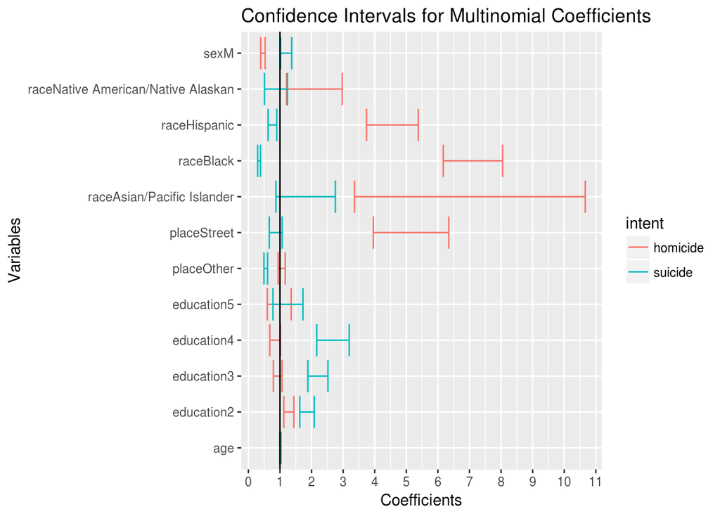

```r
errors <- tibble(vars = rep('NA', 14),
                 upper_homicide = rep(0, 14),
                 lower_homicide = rep(0, 14),
                 upper_suicide = rep(0, 14),
                 lower_suicide = rep(0, 14))

errors$vars = colnames(coef(guns_multinom))
errors$upper_homicide = exp(coef(guns_multinom) + 1.96 * summary_multinom$standard.errors)[1, ]
errors$lower_homicide = exp(coef(guns_multinom) - 1.96 * summary_multinom$standard.errors)[1, ]
errors$upper_suicide = exp(coef(guns_multinom) + 1.96 * summary_multinom$standard.errors)[2, ]
errors$lower_suicide = exp(coef(guns_multinom) - 1.96 * summary_multinom$standard.errors)[2, ]

error <- errors %>%
  gather(intent, value, -vars) %>%
  separate(intent, c('level', 'intent')) %>%
  spread(level, value) %>%
  filter(vars != 'police', vars != '(Intercept)')

ggplot(data = error) +
  geom_errorbar(aes(x = vars, ymin = lower, ymax = upper, color = intent)) +
  coord_flip() +
  scale_y_continuous(breaks = seq(0, 11, 1)) +
  geom_hline(yintercept = 1) +
  labs(title = 'Confidence Intervals for Multinomial Coefficients', x = 'Variables',
       y = 'Coefficients')
```

### Model Fit

Lastly, we do a quick check to see how well the model fits. It’s an ungrouped multinomial model, so most diagnostics don’t apply. However, below is the McFadden’s pseudo-R2 value of 0.39. Heuristically, this indicates a decent fit for the model.

```r
model_fit <- pR2(guns_multinom)
```

```r
paste("McFadden's Pseudo-R2:", round(model_fit[['McFadden']], 4))
```

```
## [1] "McFadden's Pseudo-R2: 0.3915"
```